# 第4回 線形回帰の評価プロトコルを実装し、結果を解釈する

## 前回からの接続

第3回は、民泊のホストとして、データを整えてから線形回帰（linear regression）の式を作り、1泊の値段を付けました。整えるたびに、テストでの平均絶対誤差（MAE）を測って比べました。

ただ、そのMAEは、訓練とテストへの分け方1通りで測った数でした。分け方を変えたら、数はどれくらい変わるのでしょうか。そして、式の係数が何を言っているのかは、まだ読んでいません。今日は、題材を宇宙に移し、式の評価と係数の読み方に取り組みます。

## 今日の分析目標

写真の5色だけで、銀河までの距離はどこまで分かるかに答える。

SDSS（スローン・デジタル・スカイ・サーベイ）が分光した銀河のデータで、5色の明るさから赤方偏移を当てる線形回帰の式を作ります。その当たりを交差検証で確かめ、係数が何を言っているかを、読める形に直して説明します。

もう1つのねらいは、`for`でくり返した結果を、リストにためて並べられるようになることです。1回分を返す短い関数を作り、くり返しは関数の外の`for`で書きます。

### 公開データの世界

世の中には、データベースが山ほどあります。研究で集めたデータの多くは公開されていて、誰でも解析できます。最終レポートでは、自分が解析したいデータを、自分で見つけてもらいます。探すときの手がかりに、データの宝庫をいくつか挙げておきます（申請してから使うデータもあるので、使う前に条件を確かめてください）。

- 生命（オミクス）：遺伝子・RNA・タンパク質・代謝物・糖鎖を、まるごと測ったデータ
  - ゲノム：[GenBank](https://www.ncbi.nlm.nih.gov/genbank/)、[Ensembl](https://www.ensembl.org/)
  - トランスクリプトーム（遺伝子の働き）：[GEO](https://www.ncbi.nlm.nih.gov/geo/)
  - プロテオーム（タンパク質）：[PRIDE](https://www.ebi.ac.uk/pride/)、[UniProt](https://www.uniprot.org/)
  - メタボローム（代謝物）：[MetaboLights](https://www.ebi.ac.uk/metabolights/)
  - グライコーム（糖鎖）：[GlyCosmos](https://glycosmos.org/)、[GlyTouCan](https://glytoucan.org/)
  - がん：[TCGA（GDCで配布）](https://portal.gdc.cancer.gov/)。アルツハイマー病：[ADNI](https://adni.loni.usc.edu/)（申請が要る）
- 宇宙：[SDSS](https://www.sdss.org/)（空を広く写して調べる観測）、[Gaia](https://gea.esac.esa.int/archive/)（恒星の位置と動き）、[MAST](https://archive.stsci.edu/)（ハッブルやジェイムズ・ウェッブ宇宙望遠鏡などの観測データ）
- データの置き場：[Zenodo](https://zenodo.org/)、[Dryad](https://datadryad.org/)、[Kaggle](https://www.kaggle.com/datasets)
- 身近なデータ：[気象庁の過去の気象データ](https://www.data.jma.go.jp/risk/obsdl/)、[e-Stat（政府統計）](https://www.e-stat.go.jp/)
- 探すなら：[Google Dataset Search](https://datasetsearch.research.google.com/)

分野が変われば、データの形も、くせも違います。同じ道具を、そのデータに合わせて組み立て直す。データに合わせて柔軟に対応できることが、データサイエンスの醍醐味です。第3回は東京の民泊の料金でしたが、今日は空の銀河です。データはまったく違っても、式を作って測り、その数を確かめる手順は同じです。

今日は、宇宙のデータベースSDSS（スローン・デジタル・スカイ・サーベイ）を開きます。

### 場面

天文学者は、宇宙の中で銀河がどう並んでいるか、地図を作っています。地図を作るには、一つひとつの銀河までの距離が要ります。

銀河までの距離は、光を虹のように分ける分光で、赤方偏移を測れば正確に分かります。ただし、分光は1個ずつ時間がかかります。写真なら一度に何百万個も撮れますが、分かるのは5色（u・g・r・i・z）の明るさだけです。

分光できた銀河を手がかりに、写真の5色だけで赤方偏移を当てる式を作りたい。天文学で実際に使われている、測光的赤方偏移（photometric redshift）の考え方です。

### 手元のデータ

SDSSのデータベースから取った、空の一角（赤経150〜170度、赤緯0〜10度）の銀河14,983個です。1行が1個の銀河です。

- u・g・r・i・z：5色のフィルターで測った明るさ（等級）。数が大きいほど暗い。uは紫外、gは緑、rは赤、iとzは赤外に近い光
- 赤方偏移：分光で測った、光が赤い側にずれた割合。遠い銀河ほど大きい。近い銀河なら、赤方偏移に約140億光年を掛けると、およその距離になる

今日は「分光できたのは1,000個だけ」という場面にして、14,983個から1,000個を抜き出して使います（0節）。

### 最後に出す答え

写真の5色から、赤方偏移をどれくらいの外れで当てられるか（交差検証のMAE）です。そして、5色の式の係数が何を言っているかを、読める形に直して説明します。

### 今日の一周（結果だけ先に）

コードの説明はあとにして、今日の解析を、結果だけで一度通して見ておきます。

1. 作って測る：5色で式を作ると、テストの銀河で、赤方偏移は平均0.0187外れます。距離に直すと約2.6億光年です。14億光年ほど先の銀河までの距離を、この外れで当てています。
2. 信じてよいか確かめる：分け方を20通りに変えると、MAEは0.0165〜0.0201と揺れます。1回の分け方の数は、そのまま信じられません。
3. 比べて選ぶ：uを外した式と、交差検証で比べます。5色の式は0.0191、uを外すと0.0223で、5つの組すべてで5色の式が勝ちます。
4. 説明する：rだけで当てると、rの係数はプラス（暗いほど遠い）です。ところが5色を一緒に入れると、マイナスになります。色の差で式を作り直すと、予測は1つも変わらないのに、rの係数はプラスに戻ります。

このあと、この4つの段の中身を、1つずつ開けていきます。

### 今日の問いとやること

| 段 | 問い | やること |
| --- | --- | --- |
| 作って測る（1・2節） | どのくらい外れる？ | 5色で式を作り、テストの銀河で外れを測る |
| 信じてよいか確かめる（3節） | その数字は、どこまで信じてよい？ | 分け方を20通りに変えて、MAEの揺れを見る |
| 比べて選ぶ（4・5節） | uは要る？ | 同じ分け方どうしで比べ、交差検証で比べ直す |
| 説明する（6・7節） | 係数は読める？ | rの係数を読み、相関を見て、色の差で式を作り直す |

### 今日の進め方

段ごとに、まずスライドで、その段の結論までを通して聞きます。段の終わりにノートへ移り、その段の節のセルを上から実行して、スライドと同じ数が出るかを確かめます。そして、段ごとに1つある問いに答えます。

段2から段4の問いは、実行の前に結果を予想して書き、1か所を替えて実行し、予想と比べる形です。予想が外れても、かまいません。

## 学習ゴール

この回を終えると、次のことができるようになります。

- 線形回帰の式で赤方偏移を当て、MAEを距離に直して読める
- 訓練とテストへの分け方を変えると、MAEが揺れることを確かめられる
- 2つの式を、同じ分け方どうしで比べる理由を説明できる
- 交差検証（cross-validation）で、全部の行を1度ずつテストに回して式を評価できる
- 相関の強い列を一緒に入れると係数が読めなくなること（多重共線性）を説明し、列を作り直して読める形にできる
- `for`の結果を、リストに`append`でためて並べられる

## 0. 準備

### 最初に実行する：道具を呼び出す

- 役割：このノートで使う道具（ライブラリ）を呼び出す
- 入力：なし
- 出力：なし（終わるとセルの左に ✓ が付く）

```python
import numpy as np
import pandas as pd
import matplotlib.pyplot as plt
from sklearn.linear_model import LinearRegression
from sklearn.model_selection import train_test_split
```

### 図の日本語を表示できるようにする

- 役割：図の中の日本語が □ にならないようにし、図の大きさと字の大きさをそろえる
- 入力：なし
- 出力：「セットアップ完了」の表示

`try:`から先は、日本語表示の道具が動かなくなったときの保険で、中身は読まなくてかまいません。

```python
# 日本語が図の中で □ になるのを防ぐ
!pip install -q japanize-matplotlib
try:
    import japanize_matplotlib
# japanize が動かなくなったときの保険：同梱フォントを直接登録する
except Exception:
    from importlib.util import find_spec
    from matplotlib import font_manager as fm
    from pathlib import Path
    spec = find_spec('japanize_matplotlib')
    ttf = None
    if spec:
        ttf = next(Path(spec.origin).parent.rglob('*.ttf'), None)
    if ttf:
        fm.fontManager.addfont(str(ttf))
        name = fm.FontProperties(fname=str(ttf)).get_name()
        plt.rcParams['font.family'] = name

plt.rcParams['figure.figsize'] = (9, 5)
plt.rcParams['font.size'] = 13
plt.rcParams['axes.unicode_minus'] = False  # マイナス記号の化けを防ぐ
print('セットアップ完了')
```

```
セットアップ完了
```

### お手本：表を読み込む

- 役割：銀河の表を読み込み、5色のほかの列の名前を日本語にして、先頭5行を見る
- 入力：データの置き場所`DATA_DIR`と、ファイル名`sdss_galaxies.csv`
- 出力：表`raw`（14,983個の銀河）

5色の列は、フィルターの名前（u・g・r・i・z）のままにします。天文学でも、この名前で呼びます。ほかの列は日本語に付け替えます。`specobjid`は分光したときの番号、`ra`と`dec`は空の位置（赤経・赤緯）です。答えの列`redshift`は`赤方偏移`にします。z帯の明るさ`z`と取り違えないためです。

```python
# データはこのリポジトリから読み込む
DATA_DIR = ('https://raw.githubusercontent.com/k0heiun0/'
            'applied_exercise_preview/main/shared/data')
raw = pd.read_csv(f'{DATA_DIR}/sdss_galaxies.csv')
raw = raw.rename(columns={'specobjid': '分光の番号', 'ra': '赤経',
                          'dec': '赤緯', 'redshift': '赤方偏移'})
print(len(raw), '個')
raw.head()
```

```
14983 個
```

|  | 分光の番号 | 赤経 | 赤緯 | u | g | r | i | z | 赤方偏移 |
| --- | --- | --- | --- | --- | --- | --- | --- | --- | --- |
| 0 | 301761268518250496 | 150.35900 | 0.08245 | 19.172 | 17.764 | 17.097 | 16.698 | 16.368 | 0.03267 |
| 1 | 301763192663599104 | 150.36375 | 0.10314 | 19.991 | 18.264 | 17.094 | 16.623 | 16.312 | 0.18533 |
| 2 | 301771713878714368 | 150.25609 | 0.02155 | 19.475 | 17.437 | 16.488 | 16.015 | 15.662 | 0.08912 |
| 3 | 301771988756621312 | 150.23171 | 0.08651 | 18.027 | 16.442 | 15.685 | 15.276 | 14.957 | 0.03275 |
| 4 | 301772263634528256 | 150.25644 | 0.03832 | 19.126 | 17.124 | 16.225 | 15.802 | 15.485 | 0.08735 |

### お手本：分光できた1,000個を抜き出す

- 役割：14,983個から1,000個を抜き出し、5色の列の名前を`bands`にしまう
- 入力：表`raw`
- 出力：表`df`（1,000個）と、赤方偏移の要約

`sample(1000, random_state=0)`は、行を1,000個、くじで選びます。`random_state`を決めておくと、何度実行しても同じ1,000個になります。

**書き方メモ（読み飛ばしてよい）**

`reset_index(drop=True)`は、抜き出した行に、0から振り直した行の番号を付けます。元の表での番号は捨てます。これで、`df`の行の番号は0〜999になります。

```python
df = raw.sample(1000, random_state=0).reset_index(drop=True)
bands = ['u', 'g', 'r', 'i', 'z']
print(len(df), '個')
print(df['赤方偏移'].describe().round(3))
print((df['赤方偏移'] > 0.2).sum(), '個は赤方偏移が0.2より大きい')
```

```
1000 個
count    1000.000
mean        0.107
std         0.052
min         0.004
25%         0.071
50%         0.099
75%         0.137
max         0.343
Name: 赤方偏移, dtype: float64
58 個は赤方偏移が0.2より大きい
```

赤方偏移は0.004〜0.343で、中央値は0.099です。中央値の銀河までは、0.099 × 140億光年で、およそ14億光年です。赤方偏移が0.2より大きい遠い銀河は、58個だけです。

## 1. 5色で式を作る

ここから、段1「作って測る」（1・2節）です。問いは、写真の5色で、赤方偏移がどのくらい外れずに当たるか、です。

表が整いました。まず第2回と同じ手順で、訓練とテストに分けて線形回帰の式を作ります。

### お手本：分けて、式を作り、予測する

- 役割：銀河を訓練7.5割・テスト2.5割に分け、5色で赤方偏移を当てる式を作り、テストの銀河を予測する
- 入力：表`df`と、5色の列の名前`bands`
- 出力：訓練とテストの個数

式は次の形です。$x_{i1}, \dots, x_{i5}$が$i$番目の銀河の5色の等級、$b_1, \dots, b_5$が係数、$b_0$が切片です。

$$\hat{y}_i = b_0 + b_1 x_{i1} + b_2 x_{i2} + \cdots + b_5 x_{i5}$$

```python
tr, te = train_test_split(df, test_size=0.25, random_state=0)
m = LinearRegression().fit(tr[bands], tr['赤方偏移'])
pred = m.predict(te[bands])
print(len(tr), len(te))
```

```
750 250
```

訓練が750個、テストが250個です。テストの250個は、式を作るのに使っていない銀河です。

## 2. どのくらい外れる？

式ができて、テストの銀河を予測しました。どのくらい外れたかを測ります。

### おさらい：平均絶対誤差（MAE）

$y_i$は$i$番目の銀河の実際の赤方偏移、$\hat{y}_i$はその予測です。外れの大きさ$\lvert y_i - \hat{y}_i \rvert$を、全部の銀河で平均したものがMAEです。

$$\text{MAE} = \frac{1}{n}\sum_{i=1}^{n} \lvert y_i - \hat{y}_i \rvert$$

式の係数は、外れの二乗の和が最小になるように決めました（第2回の最小二乗法）。でも、成績はMAEで測ります。式を作る基準と、成績を測る物差しは、別々に選んでかまいません。MAEなら、赤方偏移が平均でいくつ外れるかを、そのまま言えます。

### お手本：外れを測る

- 役割：テストの銀河ごとの外れの大きさを出し、MAE・距離に直したMAE・決定係数（coefficient of determination）R²を表示する
- 入力：テストの表`te`と予測`pred`
- 出力：MAE、距離に直したMAE（億光年）、R²

`np.abs`は絶対値です。`m.score(...)`は、第2回で使った決定係数R²を返します。

```python
err = np.abs(te['赤方偏移'] - pred)          # 外れの大きさ
print(round(err.mean(), 4))                  # MAE
print(round(err.mean() * 140, 1), '億光年')   # 距離に直す
print(round(m.score(te[bands], te['赤方偏移']), 2))  # R²
```

```
0.0187
2.6 億光年
0.74
```

MAEは0.0187です。距離に直すと、約2.6億光年の外れです。14億光年ほど先の銀河までの距離を、写真の5色だけで、この外れで当てています。R²は0.74で、赤方偏移のばらつきの7割あまりを、5色で説明できています。

### お手本：予測と実際を並べて描く

- 役割：横軸に実際の赤方偏移、縦軸に予測をとって、テストの銀河を点で描く
- 入力：テストの表`te`と予測`pred`
- 出力：散布図

灰色の線は「予測＝実際」の線です。線に近い点ほど、よく当たっています。

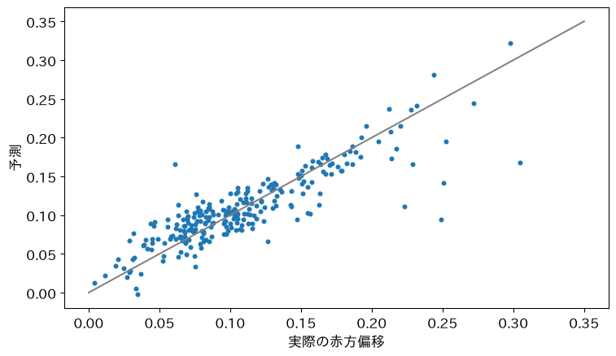

```python
plt.scatter(te['赤方偏移'], pred, s=12)
plt.plot([0, 0.35], [0, 0.35], color='gray')
plt.xlabel('実際の赤方偏移')
plt.ylabel('予測')
plt.show()
```

点はおおむね線に沿っています。ただ、線から大きく離れた点もあります。

### お手本：大きく外れた銀河を見る

- 役割：外れが0.05以上の銀河を数え、その銀河の5色と赤方偏移を表示する
- 入力：外れの大きさ`err`と、テストの表`te`
- 出力：大きく外れた銀河の数、いちばん大きな外れ、その銀河たちの表

`err >= 0.05`は、外れが0.05以上かどうかのTrue/Falseの並びです。`te[...]`に渡すと、Trueの行だけが残ります（第1回の、条件で絞る書き方です）。

```python
big = err >= 0.05
print(big.sum(), '個')
print(round(err.max(), 3), round(err.max() * 140, 1), '億光年')
print((te[big]['赤方偏移'] > 0.2).sum(), '個は0.2より大きい')
te[big][bands + ['赤方偏移']]
```

```
13 個
0.155 21.7 億光年
6 個は0.2より大きい
```

|  | u | g | r | i | z | 赤方偏移 |
| --- | --- | --- | --- | --- | --- | --- |
| 710 | 23.203 | 19.362 | 17.752 | 17.222 | 16.920 | 0.30459 |
| 230 | 22.235 | 18.765 | 17.306 | 16.724 | 16.363 | 0.25053 |
| 262 | 21.236 | 18.875 | 17.558 | 17.071 | 16.786 | 0.25214 |
| 202 | 19.365 | 18.218 | 17.624 | 17.301 | 17.097 | 0.15624 |
| 386 | 23.241 | 19.092 | 17.660 | 17.111 | 16.770 | 0.24886 |
| 568 | 19.953 | 18.484 | 17.560 | 17.078 | 16.854 | 0.22898 |
| 780 | 20.404 | 18.579 | 17.752 | 17.322 | 17.054 | 0.22332 |
| 990 | 19.928 | 18.287 | 17.379 | 16.916 | 16.564 | 0.07590 |
| 320 | 19.412 | 18.221 | 17.553 | 17.230 | 16.934 | 0.15459 |
| 751 | 20.089 | 18.265 | 17.394 | 17.013 | 16.742 | 0.06313 |
| 894 | 19.287 | 17.868 | 16.819 | 16.326 | 15.944 | 0.06069 |
| 294 | 19.699 | 18.196 | 17.559 | 17.262 | 17.114 | 0.14715 |
| 462 | 19.111 | 17.720 | 17.124 | 16.865 | 16.607 | 0.12623 |

250個のうち13個で、0.05以上外れました。いちばん大きな外れは0.155で、距離に直すと21.7億光年です。13個のうち6個は、赤方偏移が0.2より大きい遠い銀河です。MAEは「平均でどれだけ外れるか」なので、こうした大外れは見えません。大外れは1個ずつ見ます。

### やってみよう：大きく外れた銀河を、どう扱うか

上の表で、大きく外れた銀河の赤方偏移を見てください。半分近くは、赤方偏移が0.2より大きい遠い銀河です。この式を使って銀河の地図を作るとき、大きく外れる銀河があることを、どう扱いますか。下に書いてください。

（ここに答えを書く）

考え方の例：大外れの半分近くは遠い銀河で、式は遠い銀河を近めに当てています（表の予測は省きましたが、散布図の右側の点が線より下にあります）。遠い銀河は、手元の1,000個の中に58個しかなく、式は遠い銀河をあまり学べていません。地図には「赤方偏移が0.2を超えそうな銀河は、外れが大きい」と注意書きを付けるか、そうした銀河は分光で測り直す候補にします。MAEだけを報告せず、大外れの数も一緒に伝えます。

### ここまでで分かったこと

| 段 | 分かったこと |
| --- | --- |
| 作って測る（1・2節） | 5色で赤方偏移が平均0.0187外れる（約2.6億光年）。大外れは1個ずつ見る |
| 信じてよいか確かめる（3節） | ？（このあとの段で） |
| 比べて選ぶ（4・5節） | ？（このあとの段で） |
| 説明する（6・7節） | ？（このあとの段で） |

まだ分からないのは、0.0187という数を、どこまで信じてよいか、です。

## 3. その数字、どこまで信じる？

ここから、段2「信じてよいか確かめる」（3節）です。問いは、その数字はどこまで信じてよいか、です。

1・2節のMAEは、`random_state=0`という1通りの分け方で出した数です。分け方を変えたら、同じ数が出るのでしょうか。

### おさらい：for文と関数

`for 変数 in 並び:`は、並びの中身を1つずつ変数に入れて、字下げした行をくり返します。`range(3)`は0・1・2の3つの数です。

`def 名前(引数):`で関数を作り、`return`の後ろが戻り値です。

```python
def double(x):
    return x * 2

for s in range(3):
    print(double(s))   # 0, 2, 4 と順に表示される
```

### お手本：1回分のMAEを返す関数

- 役割：分け方の番号`s`で訓練とテストに分け、式を作って、テストのMAEを返す
- 入力：表`df`、手がかりの列の名前`cols`、分け方の番号`s`
- 出力：MAE（1つの数）

中の4行は、1・2節でやったこと（分ける・当てはめる・予測する・測る）を、そのまま並べたものです。`random_state=0`を`random_state=s`に替えたので、`s`を変えると分け方が変わります。

```python
def one_mae(df, cols, s):
    tr_s, te_s = train_test_split(df, test_size=0.25, random_state=s)
    m_s = LinearRegression().fit(tr_s[cols], tr_s['赤方偏移'])
    pred_s = m_s.predict(te_s[cols])
    return np.abs(te_s['赤方偏移'] - pred_s).mean()

print(round(one_mae(df, bands, 0), 4))
```

```
0.0187
```

`s = 0`では0.0187で、2節と同じ数です。

### 新しい書き方：リストにためる

くり返しの結果を、1つずつためておく入れ物がリストです。`[]`で空のリストを作り、`append(値)`で後ろに1つ足します。

```python
x = []           # 空のリスト
x.append(5)      # x は [5]
x.append(7)      # x は [5, 7]
```

**書き方メモ（読み飛ばしてよい）**

リストの`append`は、後ろに1つ足すだけです。何度くり返しても速く、メモリもほとんど余分に使いません。

注意が要るのは、NumPyの配列に足す`np.append(配列, 値)`です。こちらは、足すたびに配列をまるごと作り直します。`for`で何千回もくり返すと遅くなり、メモリも余分に使います。

くり返しの結果は、今日のようにリストにためてから、最後に`np.mean(maes)`のようにまとめて計算します。

### お手本：分け方を20通り変える

- 役割：分け方の番号を0〜19に変えて`one_mae`を呼び、20回分のMAEをリスト`maes`にためる
- 入力：表`df`、5色の列`bands`
- 出力：MAEの最小と最大、平均

`for`は関数の外にあります。関数は1回分だけを受け持ち、くり返しは`for`が受け持ちます。

```python
maes = []
for s in range(20):
    maes.append(one_mae(df, bands, s))
print(round(min(maes), 4), round(max(maes), 4))
print(round(np.mean(maes), 4))
```

```
0.0165 0.0201
0.0185
```

`for`が1回まわるたびに、`maes`の後ろに1つ増えます。下の図の赤い箱が、その回に`append`で足した1つです。20回まわると、20個のMAEがたまります。

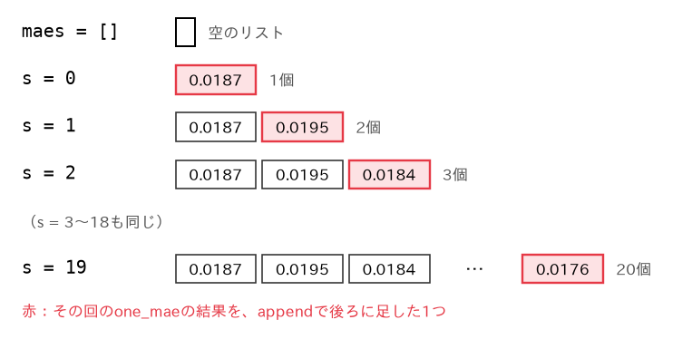

MAEは、最小0.0165から最大0.0201まで揺れます。平均は0.0185です。2節の0.0187は、この20通りのうちの1つにすぎません。

点で描いて、揺れを見ます。

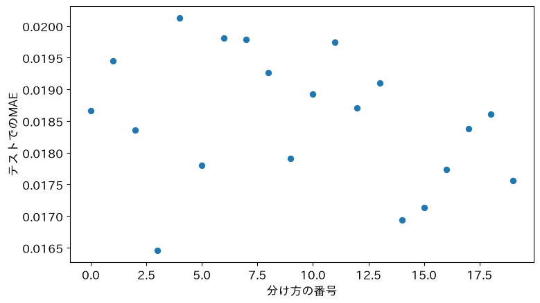

```python
plt.plot(maes, 'o')
plt.xlabel('分け方の番号')
plt.ylabel('テストでのMAE')
plt.show()
```

同じ式、同じ1,000個の銀河なのに、どの250個がテストに入るかだけで、MAEが上下します。0.0165なら「よく当たる」、0.0201なら「まあまあ」と、評価まで変わってしまいます。

> 今日の重要概念（Python）：リストにためる

> くり返しの結果は、空のリストを作り、`for`の中で`append`して1つずつためる。ためておくと、20個を並べて、最小・最大・平均を出せる。

### TODO①：銀河の数を替える（予想 → 実行 → 比べる）

下のセルは、14,983個から1,000個を抜き出し、20通りの分け方でMAEを測って、揺れの幅（最大−最小）を表示します。このままだと、上と同じ1,000個なので、幅は上と同じです。

まず、予想を書いてください。銀河を300個に減らすと、揺れの幅はどうなるでしょうか。

（ここに予想を書く）

予想を書いたら、セルの`1000`を`300`に替えて実行してください。余裕があれば、`len(raw)`（14,983個すべて）にも替えて実行してみましょう。

```python
# TODO: 1000 を 300 に替えて実行する
df_n = raw.sample(1000, random_state=0).reset_index(drop=True)
maes_n = []
for s in range(20):
    maes_n.append(one_mae(df_n, bands, s))
print(round(max(maes_n) - min(maes_n), 4))
```

```
0.0037
```

### やってみよう：予想と比べる

実行した結果を、予想と比べてください。揺れの幅は、銀河の数でどう変わりましたか。下に書いてください。

（ここに答えを書く）

1,000個では幅0.0037でした。300個に減らすと0.0069で、2倍近くに広がります。`len(raw)`に替えて14,983個すべてを使うと、幅はさらに縮みます。銀河が少ないほど、どの銀河がテストに入るかの運が大きく効き、1回の分け方の数は当てにならなくなります。

### ここまでで分かったこと

| 段 | 分かったこと |
| --- | --- |
| 作って測る（1・2節） | 5色で赤方偏移が平均0.0187外れる（約2.6億光年）。大外れは1個ずつ見る |
| 信じてよいか確かめる（3節） | MAEは分け方だけで0.0165〜0.0201と揺れる。銀河が少ないほど揺れる |
| 比べて選ぶ（4・5節） | ？（このあとの段で） |
| 説明する（6・7節） | ？（このあとの段で） |

まだ分からないのは、揺れる数どうしで、どうやって式を比べるか、です。

## 4. uを外すと？

ここから、段3「比べて選ぶ」（4・5節）です。問いは、5色のうちuは要るか、です。

uは紫外の光で、5色の中でいちばん暗く、測りにくい色です。uを外した4色の式と、5色の式を比べます。ただ、MAEは分け方だけで揺れました。どう比べればよいでしょうか。

### お手本：uを外した式も、同じ20通りで測る

- 役割：uを外した4色の列`no_u`で、3節と同じ20通りの分け方のMAEをリスト`maes_no_u`にためる
- 入力：表`df`、列の名前`no_u`
- 出力：MAEの平均

`one_mae`に渡す列の組を替えるだけで、別の式を測れます。

```python
no_u = ['g', 'r', 'i', 'z']
maes_no_u = []
for s in range(20):
    maes_no_u.append(one_mae(df, no_u, s))
print(round(np.mean(maes_no_u), 4))
```

```
0.0216
```

uを外した式のMAEは、平均0.0216です。5色の式（0.0185）より悪くなりました。

### お手本：同じ分け方どうしで勝ち負けを数える

- 役割：分け方の番号ごとに、5色の式とuを外した式のMAEを比べ、5色の式が勝った回数を数える
- 入力：2つのリスト`maes`と`maes_no_u`
- 出力：5色の式が勝った回数

`maes[s]`は、リストの`s`番目（0から数える）の値です。番号`s`が同じなら、テストの250個がまったく同じです。同じ銀河で測った2つのMAEなら、差は式の違いだけから生まれます。

```python
wins = 0
for s in range(20):
    if maes[s] < maes_no_u[s]:
        wins = wins + 1
print(wins, '回は5色の式が勝った')
```

```
20 回は5色の式が勝った
```

20回すべてで、5色の式が勝ちました。MAEそのものは分け方で揺れても、同じ分け方どうしの勝ち負けは、いつも同じです。

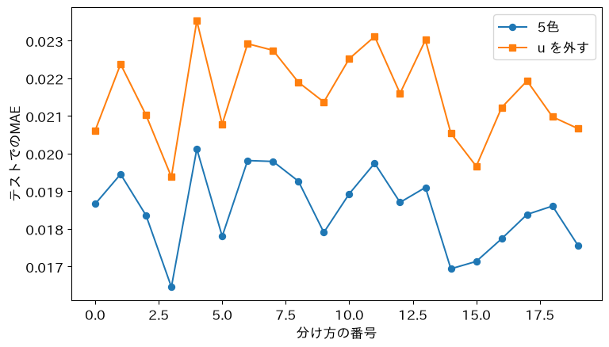

```python
plt.plot(maes, 'o-', label='5色')
plt.plot(maes_no_u, 's-', label='u を外す')
plt.xlabel('分け方の番号')
plt.ylabel('テストでのMAE')
plt.legend()
plt.show()
```

2本の線は、分け方ごとに一緒に上がったり下がったりします。そして、どの分け方でも、uを外した式（四角）が上にあります。

### 別々の分け方どうしで比べると

[output not shown]

380組のうち9組で、uを外した式のほうが良く見えました。たまたま当てやすい銀河がテストに入った分け方と比べると、悪い式が良く見えてしまうのです。式を比べるときは、同じ分け方どうしで並べます。

## 5. 全部の銀河を1度ずつテストに

同じ分け方どうしで並べれば、式を比べられることが分かりました。ただ、20回の分け直しでは、何度もテストに入る銀河と、一度も入らない銀河が出てきます。どの銀河も、ちょうど1度ずつテストに入るように分けられないでしょうか。

### 交差検証：全部の行を1度ずつテストにする

銀河を、重ならない5つの組に分けます。1回目は組0をテストに、残りの4組を訓練にして、式を作ってMAEを測ります。2回目は組1をテストに……と、5回くり返します。5回で、どの銀河もちょうど1度ずつテストに入ります。最後に、5回のMAEを平均します。

$$\text{CV} = \frac{1}{K}\sum_{k=1}^{K} \text{MAE}_k$$

$K$は組の数（今日は5）、$\text{MAE}_k$は$k$番目の組をテストにしたときのMAEです。このやり方を、$K$分割交差検証（K-fold cross-validation, CV）と呼びます。平均するのはMAEでなくてもよく、ほかの外れの物差しでも同じ手順で比べられます。

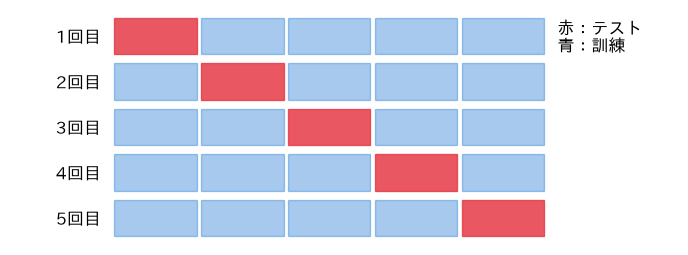

### お手本：銀河に組の番号を振る

- 役割：1,000個の銀河に、組の番号0〜4を振り、組ごとの個数を確かめる
- 入力：表`df`
- 出力：組ごとの個数

`df.index`は行の番号（0〜999）です。`%`は割った余りで、`df.index % 5`は0, 1, 2, 3, 4, 0, 1, …と、5つの番号を順に振ります。`df`は0節でくじで抜き出したので、行の並びはもともとばらばらです。

```python
df['組'] = df.index % 5
print(df['組'].value_counts())
```

```
組
0    200
1    200
2    200
3    200
4    200
Name: count, dtype: int64
```

組0〜4に、200個ずつ入りました。

### お手本：交差検証の関数

- 役割：組`k`をテスト、残りを訓練にして式を作り、5回分のMAEをリストにためて返す
- 入力：手がかりの列の名前`cols`
- 出力：5回分のMAEのリスト

`one_mae`と比べてください。変わったのは分け方だけです。`train_test_split`の代わりに、`df['組'] != k`（組`k`でない）と`df['組'] == k`（組`k`である）で絞ります。第1回の、条件で絞る書き方です。

```python
def cv_mae(cols):
    maes_k = []
    for k in range(5):
        tr_k = df[df['組'] != k]      # 組k以外で訓練
        te_k = df[df['組'] == k]      # 組kでテスト
        m_k = LinearRegression().fit(tr_k[cols], tr_k['赤方偏移'])
        pred_k = m_k.predict(te_k[cols])
        maes_k.append(np.abs(te_k['赤方偏移'] - pred_k).mean())
    return maes_k
```

### お手本：5色の式とuを外した式を、交差検証で比べる

- 役割：2つの式を同じ5つの組で評価し、5回分のMAEと平均を並べる
- 入力：列の名前`bands`と`no_u`
- 出力：5回分のMAEと平均（2つの式）

`np.round(リスト, 4)`は、リストの中身を小数第4位で丸めて表示します。

```python
cv5 = cv_mae(bands)
cv4 = cv_mae(no_u)
print(np.round(cv5, 4), round(np.mean(cv5), 4))
print(np.round(cv4, 4), round(np.mean(cv4), 4))
print(round(np.mean(cv5) * 140, 1), '億光年')   # 5色の式を距離に直す
```

```
[0.0204 0.018  0.0209 0.0186 0.0179] 0.0191
[0.0223 0.0205 0.024  0.0225 0.0224] 0.0223
2.7 億光年
```

5色の式は平均0.0191（距離に直すと約2.7億光年）、uを外した式は0.0223です。5つの組すべてで、5色の式のほうがMAEが小さくなりました。uは、暗くて測りにくい色でも、赤方偏移を当てる手がかりになっています。

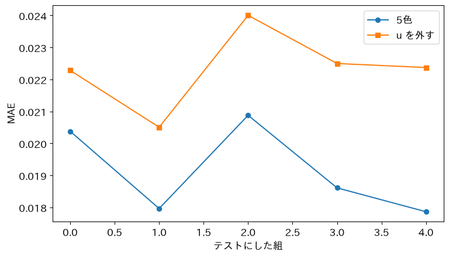

```python
plt.plot(cv5, 'o-', label='5色')
plt.plot(cv4, 's-', label='u を外す')
plt.xlabel('テストにした組')
plt.ylabel('MAE')
plt.legend()
plt.show()
```

> 今日の重要概念（統計）：交差検証

> 1回の分け方の数は揺れる。だから、全部の行を1度ずつテストに回し、外れ（今日はMAE）を平均する。2つの式は、同じ組どうしで比べる。

交差検証は、どの銀河もちょうど1度ずつテストに入るので、偏りなく式を評価できます。そして、2つの式を同じ5つの組で評価するので、いつも同じ分け方どうしで比べられます。式を比べるときの、標準の物差しです。

### TODO②：外す色を替える（予想 → 実行 → 比べる）

uのほかの色を外すと、どうなるでしょうか。まず、予想を書いてください。5色のうち、どの色を外すと、いちばん悪くなるでしょうか。

（ここに予想を書く）

予想を書いたら、下のセルの列の並びを、別の色を1つ外した並びに替えて実行してください。今はuを外した並びです。たとえばgを外すなら`['u', 'r', 'i', 'z']`です。いくつか試してみましょう。

```python
# TODO: 別の色を1つ外した並びに替えて実行する
cols_x = ['g', 'r', 'i', 'z']
print(round(np.mean(cv_mae(cols_x)), 4))
```

```
0.0223
```

### やってみよう：予想と比べる

実行した結果を、予想と比べてください。どの色を外すといちばん悪くなりましたか。外しても、あまり変わらない色はありましたか。下に書いてください。

（ここに答えを書く）

5色の式は0.0191です。gを外すと0.0301で、いちばん悪くなります。uを外すと0.0223です。一方、r・i・zは、どれを外しても約0.0208で、あまり変わりません。

r・i・zの3色は、どれか1つを外しても、残りの2色がほとんど同じことを知っているようです。この3色の関係が、次の段の入り口になります。

### ここまでで分かったこと

| 段 | 分かったこと |
| --- | --- |
| 作って測る（1・2節） | 5色で赤方偏移が平均0.0187外れる（約2.6億光年）。大外れは1個ずつ見る |
| 信じてよいか確かめる（3節） | MAEは分け方だけで0.0165〜0.0201と揺れる。銀河が少ないほど揺れる |
| 比べて選ぶ（4・5節） | 交差検証で比べると、5色の式（0.0191）がuを外した式（0.0223）に勝つ |
| 説明する（6・7節） | ？（このあとの段で） |

残るのは、この式が何を言っているか、です。

## 6. rの係数はなぜマイナス？

ここから、段4「説明する」（6・7節）です。問いは、この式の係数は読めるか、です。

当たりの良い式が決まりました。次は、式の係数を読みます。まず、rだけで当てる式と、5色の式で、rの係数を比べます。

### 係数の読み方

式$\hat{y}_i = b_0 + b_1 x_{i1} + \cdots + b_5 x_{i5}$で、ほかの列の値を全部そのままにして、$x_{ij}$だけを1増やすと、予測$\hat{y}_i$は$b_j$だけ変わります。係数$b_j$は「ほかの列を同じにしたまま、その列を1増やすと、予測がどれだけ変わるか」です。

### お手本：rだけの式と、5色の式の係数

- 役割：1,000個すべてで、rだけの式と5色の式を作り、係数を表示する
- 入力：表`df`
- 出力：rだけの式の係数と、5色の式の係数

`pd.Series(m.coef_, index=列の名前)`で、係数に列の名前を付けて表示します。

```python
m_r = LinearRegression().fit(df[['r']], df['赤方偏移'])
m_all = LinearRegression().fit(df[bands], df['赤方偏移'])
print(m_r.coef_.round(3))
print(pd.Series(m_all.coef_, index=bands).round(3))
```

```
[0.033]
u   -0.058
g    0.314
r   -0.214
i   -0.216
z    0.192
dtype: float64
```

rだけの式では、rの係数は+0.033です。rで1等暗い銀河は、赤方偏移が0.033大きい、つまり遠い。直感どおりです。

ところが、5色の式では、rの係数は−0.214です。「ほかの4色を同じにしたまま、rだけ1等暗いと、近い」と読めてしまいます。暗いほど近い、ということがあるのでしょうか。

### お手本：5色どうしの相関

- 役割：5色の等級どうしの相関係数を表にする
- 入力：表`df`と`bands`
- 出力：相関係数の表

`corr()`は、列どうしの相関係数を表にします。

```python
print(df[bands].corr().round(3))
```

```
       u      g      r      i      z
u  1.000  0.916  0.758  0.688  0.620
g  0.916  1.000  0.943  0.904  0.859
r  0.758  0.943  1.000  0.988  0.974
i  0.688  0.904  0.988  1.000  0.993
z  0.620  0.859  0.974  0.993  1.000
```

rとiの相関は0.988、iとzは0.993です。rで暗い銀河は、iでもzでも暗いのです。5色は、ほとんど同じことを言っています。

「ほかの4色を同じにしたまま、rだけ1等暗い」銀河は、実際にはまずありません。そんな銀河は、色がまったく違う銀河です。−0.214は、ありえない比べ方の答えなのです。

### お手本：分け方を替えると、rの係数は？

- 役割：分け方の番号`s`で分けて式を作り、rの係数を返す関数を作り、20通りの分け方でrの係数をためる
- 入力：手がかりの列の名前`cols`（rを含む）、分け方の番号`s`
- 出力：20回分のrの係数の最小と最大

`one_mae`と同じ形で、最後の行だけが違います。MAEの代わりに、係数のうちrのものを返します。

```python
def r_coef(cols, s):
    tr_s, te_s = train_test_split(df, test_size=0.25, random_state=s)
    m_s = LinearRegression().fit(tr_s[cols], tr_s['赤方偏移'])
    return pd.Series(m_s.coef_, index=cols)['r']

coefs = []
for s in range(20):
    coefs.append(r_coef(bands, s))
print(round(min(coefs), 3), round(max(coefs), 3))
```

```
-0.235 -0.137
```

rの係数は、分け方だけで−0.235〜−0.137と揺れます。rだけの式の+0.033と比べると、符号が逆で、大きさも分け方しだいです。

相関の強い列を一緒に式に入れると、予測はよく当たっても、係数は不安定になり、読めなくなります。これを、多重共線性（multicollinearity）と呼びます。

> 重要：多重共線性

> 相関の強い列を一緒に入れると、予測は良くても、係数は揺れて読めない（多重共線性）。係数を読む前に、列どうしの相関を見る。

## 7. 係数を読める式にするには？

5色の係数は、多重共線性で読めませんでした。でも、当たりは良い式です。当たりを保ったまま、係数を読める式に作り直せないでしょうか。

天文学者は、5色の明るさそのものより、隣り合う色の差を見ます。たとえばg − rは、緑で見た明るさと赤で見た明るさの差で、銀河の「色」です。遠い銀河ほど光が赤い側にずれるので、色が変わります。

### お手本：色の差の列を作る

- 役割：隣り合う色の差を4本作り、rと合わせて列の名前を`colors`にしまう
- 入力：表`df`
- 出力：新しい列の相関係数の表

列どうしの引き算は、第1回の書き方です。

```python
df['u-g'] = df['u'] - df['g']
df['g-r'] = df['g'] - df['r']
df['r-i'] = df['r'] - df['i']
df['i-z'] = df['i'] - df['z']
colors = ['u-g', 'g-r', 'r-i', 'i-z', 'r']
print(df[colors].corr().round(2))
```

```
      u-g   g-r   r-i   i-z     r
u-g  1.00  0.79  0.61  0.64 -0.01
g-r  0.79  1.00  0.54  0.79  0.13
r-i  0.61  0.54  1.00  0.36  0.11
i-z  0.64  0.79  0.36  1.00 -0.04
r   -0.01  0.13  0.11 -0.04  1.00
```

rと、ほかの4本（色の差）の相関は、どれも絶対値で0.13以下です。rは「全体の明るさ」、色の差は「色」と、別のことを言う列になりました。

### お手本：色の差の式を作り、5色の式と比べる

- 役割：色の差とrの式を作り、5色の式との予測の差の最大と、係数を表示する
- 入力：表`df`、列の名前`colors`、6節の5色の式`m_all`
- 出力：予測の差の最大、色の差の式の係数

```python
m_c = LinearRegression().fit(df[colors], df['赤方偏移'])
diff = np.abs(m_c.predict(df[colors]) - m_all.predict(df[bands]))
print(round(diff.max(), 10))
coef_c = pd.Series(m_c.coef_, index=colors)
print(coef_c.round(3))
```

```
0.0
u-g   -0.058
g-r    0.256
r-i    0.024
i-z   -0.192
r      0.018
dtype: float64
```

予測の差は、1,000個すべてで0です。色の差の4本とrがあれば、5色の等級はすべて計算で戻せるので、2つの式は同じ予測をします。

それなのに、rの係数は+0.018です。同じ予測をする式なのに、5色の式の−0.214から、符号まで変わりました。今日の一周で見た「えっ」の答えです。「色を同じにしたまま、rだけ1等暗い」とは、同じ色の銀河が、全体に暗く見えるということです。同じ種類の銀河が暗く見えるなら、遠いからです。今度は直感どおりに読めます。

g − rの係数は+0.256です。ほかを同じにしたまま、g − rが赤い（大きい）ほど、遠いと読めます。

### お手本：色の差の式で、rの係数は揺れるか

- 役割：6節の`r_coef`に色の差の列を渡し、20通りの分け方でrの係数の最小と最大を出す
- 入力：列の名前`colors`
- 出力：20回分のrの係数の最小と最大

```python
coefs_c = []
for s in range(20):
    coefs_c.append(r_coef(colors, s))
print(round(min(coefs_c), 3), round(max(coefs_c), 3))
```

```
0.016 0.02
```

rの係数は、20回とも+0.016〜+0.020に収まりました。5色の式では−0.235〜−0.137と揺れていた係数が、落ち着いています。

当たりはそのままで、係数が読めるようになりました。相関の強い列を、意味の違う列に作り直したからです。

### TODO③：rと組む色を替える（予想 → 実行 → 比べる）

6節では、5色を一緒に入れると、rの係数が分け方で揺れました。2色だけの式でも、同じことが起きるでしょうか。下のセルは、uとrの2色の式を20通りの分け方で作り、rの係数の最小と最大を出します。6節の相関の表で、uとrの相関は0.758、rとiの相関は0.988でした。

まず、予想を書いてください。rを、相関の強いiと組ませると、rの係数の揺れはどうなるでしょうか。

（ここに予想を書く）

予想を書いたら、下のセルの`['u', 'r']`を`['r', 'i']`に替えて実行してください。

```python
# TODO: ['u', 'r'] を ['r', 'i'] に替えて実行する
cols_x = ['u', 'r']
coefs_x = []
for s in range(20):
    coefs_x.append(r_coef(cols_x, s))
print(round(min(coefs_x), 3), round(max(coefs_x), 3))
```

```
-0.016 -0.012
```

### やってみよう：予想と比べる

実行した結果を、予想と比べてください。uと組ませたときと、iと組ませたときで、rの係数の揺れが違うのはなぜか、1〜2文で説明してください。

（ここに答えを書く）

uと組ませると、rの係数は−0.016〜−0.012で、ほとんど揺れません。iと組ませると、0.149〜0.438と大きく揺れます。

rとiは相関が0.988で、ほとんど同じことを言う2色です。2色だけの式でも、式は2つに手柄をどう分けるかを決められず、分け方しだいで係数が大きく変わります。係数を揺らすのは、列の数ではなく、列どうしの相関です。

### ここまでで分かったこと

| 段 | 分かったこと |
| --- | --- |
| 作って測る（1・2節） | 5色で赤方偏移が平均0.0187外れる（約2.6億光年）。大外れは1個ずつ見る |
| 信じてよいか確かめる（3節） | MAEは分け方だけで0.0165〜0.0201と揺れる。銀河が少ないほど揺れる |
| 比べて選ぶ（4・5節） | 交差検証で比べると、5色の式（0.0191）がuを外した式（0.0223）に勝つ |
| 説明する（6・7節） | 5色の係数は多重共線性で読めない。色の差に作り直すと、予測は同じで係数が読める |

4つの段がそろい、今日の問いに答えられます。

### 答え

写真の5色だけで、赤方偏移は交差検証で平均0.0191の外れで当たります。距離に直すと約2.7億光年で、14億光年ほど先の銀河までの距離を、分光せずに見積もれます。

ただし、5色の等級をそのまま入れた式の係数は、多重共線性で読めません。隣り合う色の差とrで作り直すと、予測は同じまま、係数が読めます。rの係数はプラスで「同じ色なら暗いほど遠い」、g − rの係数もプラスで「赤いほど遠い」と読めます。

まだ言えないこと

- 遠い銀河ほど大きく外れる：大外れの半分近くは、赤方偏移が0.2を超える銀河だった。直線の式では表しきれない関係がありそう
- 列を増やすと：色の差の二乗など、列を増やせば当たりは良くなるかもしれない。でも、列が増えるほど、似た列も増える
- 1個の銀河：この銀河が遠いと出た理由を、色ごとに言えるかは、まだ確かめていない

## 目標に答えられたか

- 今日の目標は「写真の5色だけで、銀河までの距離はどこまで分かるか」でした。交差検証のMAEと、それを距離に直した値で答えられますか？
- 2節で、MAEだけでは見えなかったものは何でしたか？
- 3節で、分け方を変えると、MAEはどれくらい揺れましたか？ 銀河の数を減らすと、揺れはどうなりましたか？
- 4節で、2つの式を比べるときに、同じ分け方どうしで並べたのはなぜですか？
- 5節の交差検証は、20回の分け直しと比べて、何が良いのでしょうか？
- 6節で、rの係数が、rだけの式と5色の式で逆の符号になったのはなぜですか？
- 7節で、色の差に作り直すと、予測と係数はそれぞれどうなりましたか？
- TODO③で、rをuと組ませたときとiと組ませたときで、係数の揺れが違ったのはなぜですか？

## 今日の要点

- 今日、持ち帰る1文：写真の色だけで、銀河までの距離はかなり当たる。ただし、その成績は交差検証で確かめる。相関の強い列を一緒に入れると（多重共線性）、予測は良くても係数は読めない
- 重要概念（統計）：交差検証。1回の分け方の数は揺れる。全部の行を1度ずつテストに回し、2つの式は同じ組どうしで比べる
- 重要概念（Python）：リストにためる。くり返しの結果は、空のリストを作り、`for`の中で`append`して1つずつためる
- 重要：多重共線性。相関の強い列を一緒に入れると、係数は揺れて読めない。意味の違う列に作り直すと、予測は同じまま係数が読める
- 交差検証と多重共線性はつながる：r・i・zは、どれを外しても交差検証のMAEがほとんど変わらなかった（5節）。この3色は相関が0.988・0.993と強い（6節）。外しても当たりが変わらない列どうしは、多重共線性を疑う
- 係数は「ほかの列を同じにしたまま、その列を1増やすと、予測がどれだけ変わるか」
- MAEは平均の外れ。大外れは1個ずつ見る。データが少ないほど、1回の分け方の数は揺れる

## 次回へ

今日は、5色を色の差に作り直して、係数を読める式にしました。でも、いつも作り直し方が分かるとは限りません。手がかりの列が何十本、何百本とあり、似た列がたくさんあったら、どうすればよいでしょうか。

次回の問いは、列がたくさんあるときに、当たりを保ちながら、係数を落ち着かせられるか、です。

## 課題（提出）

提出するもの：絵2枚（画像ファイル）。今日の重要概念の、統計とPythonを1枚ずつです。提出フォームから出してください。期限はありません。

コードは書きません。上手な絵である必要はありません。紙に手で描いて写真を撮っても、描画アプリで描いてもかまいません。

### 今日の重要概念（2つ）

- 統計：交差検証。全部の行を1度ずつテストに回し、MAEを平均する。2つの式は、同じ組どうしで比べる（3〜5節）
- Python：リストにためる。くり返しの結果は、空のリストを作り、`for`の中で`append`して1つずつためる（3節）

### 今日の2枚（絵にする）

2つの重要概念を、1枚ずつ絵にしてください。その考えが1枚で伝わる絵です。数式やコードは描かなくてかまいません。半年後の自分が見て、何の話だったか思い出せる絵を目指します。

**詰まったら**

交差検証なら、たとえば「データを5切れのケーキに分け、1切れずつ味見に回す」ように、全部が1度ずつテストに入る様子を描けます。 「1回だけ味見すると、たまたま当たりの1切れかもしれない」という、1回の分け方の危うさを描いてもかまいません。

**詰まったら**

リストにためるなら、たとえば「空の箱を1つ用意し、流れてくる結果を1つずつ、箱の後ろに入れていく」様子を描けます。 3節の「リストにためる」の図が手本になります。20回くり返すと20個がたまり、並べて最小・最大・平均が見える様子でもかまいません。

## 発展（任意）

### 1個の銀河を説明する：予測を、列ごとの寄与に分ける

7節で、係数が読める式ができました。その式で、1個の銀河について、予測の理由を説明します。

平均的な銀河とは、どの列も1,000個の平均$\bar{x}_j$の値をもつ銀河です。ある銀河の予測$\hat{y}$は、平均的な銀河の予測に、列ごとの寄与を足したものになります。

$$\hat{y} = \hat{y}_{\text{平均的な銀河}} + \sum_j b_j (x_j - \bar{x}_j)$$

$b_j(x_j - \bar{x}_j)$が、列$j$がこの銀河の予測を平均よりどれだけ押し上げたか（マイナスなら押し下げたか）です。

- 役割：銀河の番号`k`の銀河について、列ごとの寄与と、予測・実際の赤方偏移を表示する
- 入力：色の差の式`m_c`、係数`coef_c`、表`df`、銀河の番号`k`
- 出力：平均的な銀河の予測、この銀河の予測と実際の赤方偏移、列ごとの寄与

`df[colors].iloc[k]`は、`colors`の列だけの表から、`k`行目の銀河を取り出します。上の式を、そのまま写しています。

```python
avg = m_c.predict(df[colors]).mean()   # 平均的な銀河の予測
k = 7                                  # 銀河の番号（0から数える）
gal = df[colors].iloc[k]
push = coef_c * (gal - df[colors].mean())   # 列ごとの寄与
print(round(avg, 4), round(avg + push.sum(), 4), df['赤方偏移'][k])
print(push.round(4))
```

```
0.107 0.1422 0.1514
u-g   -0.0213
g-r    0.0717
r-i    0.0014
i-z   -0.0140
r     -0.0026
dtype: float64
```

平均的な銀河の予測は0.107です。8番目の銀河（番号7）の予測は0.1422で、実際の赤方偏移は0.1514でした。

いちばん押し上げているのはg − rで、+0.0717です。この銀河は、平均より赤い色をしています。遠い銀河ほど光が赤い側にずれるので、式は「赤いから遠い」と判断しました。

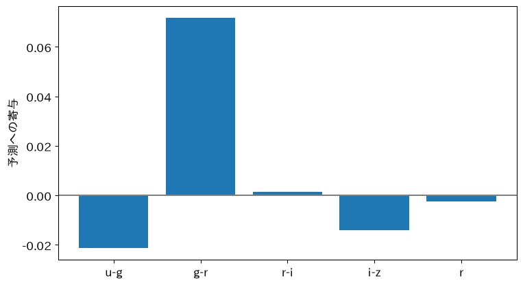

```python
plt.bar(push.index, push)
plt.axhline(0, color='gray')
plt.ylabel('予測への寄与')
plt.show()
```

番号を4に替えてみます。番号4の銀河は、実際の赤方偏移が0.038の、近い銀河です。

```python
k = 4
gal = df[colors].iloc[k]
push = coef_c * (gal - df[colors].mean())
print(round(avg + push.sum(), 4), df['赤方偏移'][k])
print(push.round(4))
```

```
0.0823 0.03825
u-g    0.0329
g-r   -0.1366
r-i   -0.0033
i-z    0.0702
r      0.0121
dtype: float64
```

番号4の銀河の予測は0.0823で、実際は0.03825です。g − rの寄与が−0.1366で、大きく押し下げています。この銀河は平均よりずっと青い色をしているので、式は「青いから近い」と判断しました。

一方で、i − zは+0.0702と押し上げていて、予測は実際より遠めに外れました。青い色の銀河は、星を盛んに作っている銀河に多く、赤い年老いた銀河とは光の分布が違います。こうした銀河は、5色の直線の式では当てにくいのです。

### 色の二乗を足す：曲がった関係を、直線の式で表す

2節の散布図では、遠い銀河ほど、式は近めに当てていました。赤方偏移と色の関係が、まっすぐでないのかもしれません。

色の差の二乗の列を足すと、線形回帰の式でも、曲がった関係を表せます。たとえば$(g-r)^2$を足すと、$g-r$が大きいところで、予測がより大きく変わる式になります。式は「列に係数を掛けて足す」形のままなので、線形回帰で当てはめられます。

- 役割：4本の色の差の二乗の列を作り、7節の`colors`に足した式を、交差検証で評価する
- 入力：表`df`、列の名前`colors`
- 出力：交差検証のMAE（色の差の式と、二乗を足した式）

`** 2`は二乗です。`colors + squares`は、2つのリストをつないだリストです。

```python
squares = []
for c in ['u-g', 'g-r', 'r-i', 'i-z']:
    df[c + 'の二乗'] = df[c] ** 2
    squares.append(c + 'の二乗')
print(round(np.mean(cv_mae(colors)), 4))
print(round(np.mean(cv_mae(colors + squares)), 4))
```

```
0.0191
0.0182
```

二乗を足すと、交差検証のMAEは0.0191から0.0182に下がります。曲がった関係を足したぶん、当たりが良くなりました。

ただ、列は5本から9本に増えました。$g-r$と$(g-r)^2$のように、似た列も増えています。列を増やすほど、多重共線性の心配も増えます。

### 自分の関数でVIFを出す

6節で、相関の強い列は係数を不安定にする（多重共線性）ことを見ました。どの列が、ほかの列とどれだけ似ているかを、1つの数で表せます。

列$j$を、ほかの全部の列で当てる線形回帰の式を作り、その決定係数を$R_j^2$とします。$R_j^2$が1に近いほど、列$j$はほかの列で説明できてしまう（似た列がある）ということです。

$$\text{VIF}_j = \frac{1}{1 - R_j^2}$$

この数を、分散拡大係数（VIF, variance inflation factor）と呼びます。列$j$の係数の揺れ（分散）が、似た列のせいで何倍に膨らむかを表します。似た列がなければ1で、大きいほど係数が揺れやすくなります。

- 役割：列の組`cols`の各列について、ほかの列で当てたR²からVIFを出す
- 入力：列の名前`cols`
- 出力：列ごとのVIF

`others`は、`cols`から列`c`を除いた列の名前のリストです。`for`で`cols`を1つずつ見て、`c`でない列だけを`append`で集めます。

```python
def vif(cols):
    out = {}
    for c in cols:
        others = []
        for o in cols:
            if o != c:
                others.append(o)
        m_v = LinearRegression().fit(df[others], df[c])
        r2 = m_v.score(df[others], df[c])
        out[c] = round(1 / (1 - r2), 1)
    return pd.Series(out)

print(vif(bands))
print(vif(colors))
```

```
u     18.7
g     77.5
r    123.3
i    228.8
z    195.3
dtype: float64
u-g    3.2
g-r    4.8
r-i    1.7
i-z    2.9
r      1.1
dtype: float64
```

5色の等級では、VIFは18.7〜228.8です。iは228.8で、係数の揺れが、似た列のせいで200倍以上に膨らんでいることになります。

色の差に作り直すと、VIFは1.1〜4.8まで下がります。7節で、rの係数が揺れなくなったことと合います。

VIFは、どの列が似た列を持っているかを見つける目安です。ただ、列をどう作り直すかは、VIFだけでは決まりません。今日の色の差のように、データの意味から考えます。

試すなら、上の二乗を足した9本の列`colors + squares`でもVIFを出し、二乗の列とその元の列のVIFがどれくらい大きいかを確かめてみましょう。

### MAEでなくRMSEで測ると？

二乗の列を足すと、交差検証のMAEは0.0191から0.0182に下がりました。では、外れの物差しを替えても、同じ結論になるでしょうか。

もう1つの物差しが、二乗平均平方根誤差（RMSE, root mean squared error）です。外れを二乗して平均し、平方根をとって、赤方偏移の単位に戻します。二乗するので、大きく外れた銀河ほど重く数えます。

$$\text{RMSE} = \sqrt{\frac{1}{n}\sum_{i=1}^{n} (y_i - \hat{y}_i)^2}$$

- 役割：5節の`cv_mae`の、外れを測る2行だけを替え、組ごとのRMSEを返す
- 入力：列の名前`cols`
- 出力：5つの組のRMSEのリスト

`np.sqrt`は平方根です。

```python
def cv_rmse(cols):
    rmses_k = []
    for k in range(5):
        tr_k = df[df['組'] != k]      # 組k以外で訓練
        te_k = df[df['組'] == k]      # 組kでテスト
        m_k = LinearRegression().fit(tr_k[cols], tr_k['赤方偏移'])
        pred_k = m_k.predict(te_k[cols])
        err2 = (te_k['赤方偏移'] - pred_k) ** 2
        rmses_k.append(np.sqrt(err2.mean()))
    return rmses_k
```

4つの式を、RMSEの交差検証で比べ直します。上から、5色の式、uを外した式、色の差の式、二乗を足した式です。

```python
cols_sq = colors + squares
r5 = cv_rmse(bands)
r4 = cv_rmse(no_u)
r_c = cv_rmse(colors)
r_sq = cv_rmse(cols_sq)
for r in [r5, r4, r_c, r_sq]:
    print(np.round(r, 4), round(np.mean(r), 4))
```

```
[0.0284 0.0234 0.0341 0.0254 0.0236] 0.027
[0.0289 0.026  0.0519 0.0304 0.0283] 0.0331
[0.0284 0.0234 0.0341 0.0254 0.0236] 0.027
[0.0247 0.0209 0.0926 0.0225 0.0223] 0.0366
```

uの結論は、RMSEでも同じです。5色の式は0.027、uを外すと0.0331で、5つの組すべてで5色の式が勝ちます。

ところが、二乗の列は、RMSEでは悪くなります。MAEでは0.0191から0.0182に良くなったのに、RMSEでは0.027から0.0366に悪くなります。組2だけ、RMSEが0.0926に跳ね上がっています。組2をテストにした式で、外れの大きい銀河を見ます。

```python
tr_2 = df[df['組'] != 2]      # 組2以外で訓練
te_2 = df[df['組'] == 2]      # 組2でテスト
m_2 = LinearRegression().fit(tr_2[cols_sq], tr_2['赤方偏移'])
pred_2 = m_2.predict(te_2[cols_sq])
err_2 = np.abs(te_2['赤方偏移'] - pred_2)
print(err_2.sort_values().tail(3).round(3))
```

```
462    0.069
302    0.166
92     1.259
Name: 赤方偏移, dtype: float64
```

92番の銀河だけが、1.259も外れました。この銀河の色を、1,000個の中央値と並べます。`df.loc[92, colors]`は、番号92の行の、`colors`の列を取り出します。

```python
print(df.loc[92, colors].round(2))     # 92番の銀河
print(df[colors].median().round(2))    # 1,000個の中央値
```

```
u-g    -0.63
g-r     1.73
r-i    -1.96
i-z     0.97
r      15.45
Name: 92, dtype: float64
u-g     1.74
g-r     0.86
r-i     0.40
i-z     0.30
r      17.14
dtype: float64
```

92番の銀河は、r − iが−1.96です。1,000個の中央値は0.4です。rだけが、iより2等級近く明るく、測り損ねかもしれません。二乗の式は、こうした見たことのない色の銀河で、大きく外れることがあります。

物差しで、結論が変わりました。MAEは平均の外れなので、1個の大外れは平均にならされます。RMSEは、1個の大外れに大きく引っぱられます。結論が分かれたら、2節と同じように、大外れを1個ずつ見ます。